# Mass Tests No Reaction Time in Utility

## 5.5 2a and 2b Combined Utility fits

This section analysis fits one $\alpha$ value to experiment 2a and 2b at the same time. These next tables show the movement durations, predicted movement durations, the fitted alpha values, and the probabilities of success. The $\alpha$ value for 2a and 2b are fit at once, so it is the same. 2c has its own $\alpha$ value.

The $\alpha$ value fitted here is -37.0504711. The SSE for experiment 2a/2b when using one alpha is 1.217e-02. The SSE for experiment 2c is 1.441e-03. The total SSE for all 3 is 1.361e-02.

Table 5.9: Experimental and predicted movement durations for the experiments.

|  | 2a Exp | 2a pred | 2b Exp | 2b pred | 2c Exp | 2c pred |
| --- | --- | --- | --- | --- | --- | --- |
| 2.47 | 0.7638165 | 0.799 | 0.8226259 | 0.782 | 0.6316043 | 0.661 |
| 3.8 | 0.8299896 | 0.855 | 0.8812989 | 0.837 | 0.7032684 | 0.706 |
| 4.7 | 0.8559532 | 0.884 | 0.9051184 | 0.865 | 0.7412180 | 0.730 |
| 6.1 | 0.8902248 | 0.921 | 0.9588485 | 0.901 | 0.7810693 | 0.760 |

Table 5.10: Probabilites of success for the experiments.

|  | 2a | 2b | 2c |
| --- | --- | --- | --- |
| 2.47 | 0.9798 | 0.8218 | 1 |
| 3.8 | 0.9815 | 0.8252 | 1 |
| 4.7 | 0.9823 | 0.8269 | 1 |
| 6.1 | 0.9834 | 0.8290 | 1 |

Table 5.11: Alpha values fitted to experiment 2a/2b, and a seperate alpha for 2c.

[output not shown]

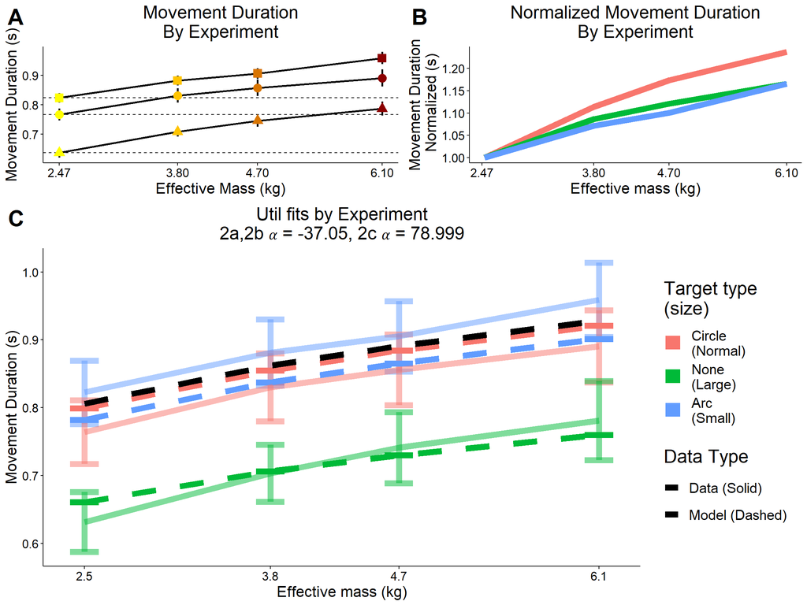

Figure 5.2: Utility fits across experiments.

## 5.6 2a Durations

### 5.6.1 MOdel Plotting Function

### 5.6.2 DF Creation

### 5.6.3 Peak Velocity Plotting

### 5.6.4 SSE of models - Exp 2a

The utility combined alpha is using the alpha value predicted off fitting a utility model to the preferred and small target experiement at the same time. This alpha value is used to make figure 5.2.

#### 5.6.4.1 Absolute

This table shows the SSE for the 2a movement duration and peak velocity predictions.

Table 5.12: Exp 2a - Sum squared errors for movement duration and peak velocity.

|  | Model | Movement Duration SSE | Movement Duration AIC | Movement Duration BIC | Peak Velocity SSE | Peak Velocity AIC | Peak Velocity BIC |
| --- | --- | --- | --- | --- | --- | --- | --- |
| SSE.2 | Accuracy Prob | 3.867e-03 | -2.58e+01 | -2.64e+01 | 7.421e-04 | -3.24e+01 | -3.30e+01 |
| SSE.3 | Met Cost Gross | 6.272e-02 | -1.46e+01 | -1.52e+01 | 3.904e-03 | -2.57e+01 | -2.63e+01 |
| SSE.4 | Met Cost Net | 2.695e-02 | -1.80e+01 | -1.86e+01 | 3.711e-03 | -2.59e+01 | -2.65e+01 |
| SSE.5 | Torque^2 | 7.337e-02 | -1.40e+01 | -1.46e+01 | 7.291e-03 | -2.32e+01 | -2.38e+01 |
| SSE.7 | Utility Gross | 8.675e-05 | -3.90e+01 | -4.02e+01 | 5.235e-04 | -3.18e+01 | -3.30e+01 |
| SSE.9 | Utility Net | 1.607e-03 | -2.73e+01 | -2.85e+01 | 1.013e-03 | -2.91e+01 | -3.04e+01 |
| SSE.10 | Utility Gross Combined Alpha | 3.597e-03 | -2.41e+01 | -2.53e+01 | 1.320e-03 | -2.81e+01 | -2.93e+01 |
| SSE.11 | Utility Net Combined Alpha | 9.006e-04 | -2.96e+01 | -3.08e+01 | 8.647e-04 | -2.98e+01 | -3.10e+01 |

#### 5.6.4.2 Normalized

Table 5.13: Exp 2a - Sum squared errors for NORMALIZED movement duration and peak velocity.

|  | Model | Movement Duration SSE | Movement Duration AIC | Movement Duration BIC | Peak Velocity SSE | Peak Velocity AIC | Peak Velocity BIC |
| --- | --- | --- | --- | --- | --- | --- | --- |
| SSE.2 | Accuracy Prob | 1.683e-02 | -1.99e+01 | -2.05e+01 | 3.270e-02 | -1.72e+01 | -1.78e+01 |
| SSE.3 | Met Cost Gross | 1.914e-03 | -2.86e+01 | -2.92e+01 | 1.153e-02 | -2.14e+01 | -2.20e+01 |
| SSE.4 | Met Cost Net | 2.137e-03 | -2.81e+01 | -2.88e+01 | 1.197e-02 | -2.12e+01 | -2.19e+01 |
| SSE.5 | Torque^2 | 7.634e-01 | -4.62e+00 | -5.24e+00 | 1.406e-01 | -1.14e+01 | -1.20e+01 |
| SSE.7 | Utility Gross | 6.460e-04 | -3.09e+01 | -3.22e+01 | 8.493e-03 | -2.06e+01 | -2.18e+01 |
| SSE.9 | Utility Net | 8.913e-04 | -2.96e+01 | -3.09e+01 | 9.197e-03 | -2.03e+01 | -2.15e+01 |
| SSE.10 | Utility Gross Combined Alpha | 6.407e-04 | -3.10e+01 | -3.22e+01 | 8.483e-03 | -2.06e+01 | -2.19e+01 |
| SSE.11 | Utility Net Combined Alpha | 8.642e-04 | -2.98e+01 | -3.10e+01 | 9.133e-03 | -2.03e+01 | -2.16e+01 |

### 5.6.5 2a Modeling Plot

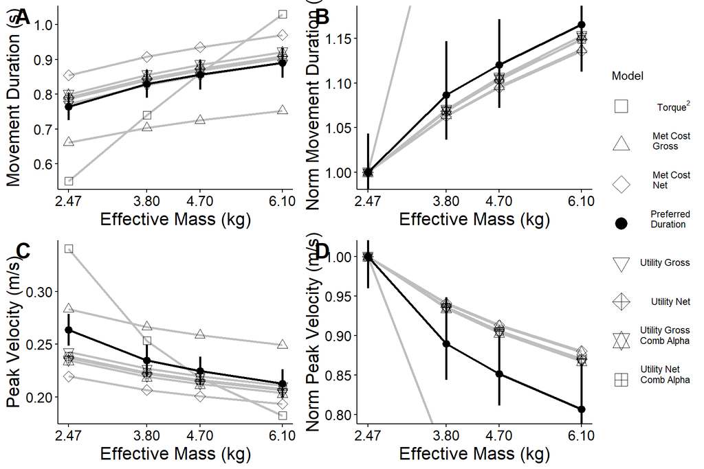

Figure 5.3: Modeling Results